# Cherry Hill School District — NJ School Data Almanac – NJ District Profiles

NJ School Data Almanac

Cherry Hill School District

CAMDEN COUNTY · TRADITIONAL PUBLIC DISTRICT · DFG GH · 10,202 STUDENTS (2026)

10,202

Students

95.2%

4-yr grad rate

62.5%

Gr 3-8 ELA

13.5%

Chronically absent

$18,916

Per pupil

*10 things the data says about Cherry Hill School District. Every figure is computed from New Jersey Department of Education data via the njschooldata package — nothing is estimated. Comparisons use District Factor Group (DFG) peers (76 districts in DFG GH).*

No. 1 ENROLLMENT

## Cherry Hill Lost 603 Students in a Single Year, Hitting Its Lowest Enrollment on Record

After clawing back to 10,805 students in 2025, the district shed 603 the very next year to fall to 10,202 — the smallest it has been since at least 2015.

Cherry Hill’s enrollment story looked, for a moment, like a recovery. After the pandemic dip, the district added 127 students in 2022, 110 more in 2023, and rebounded to 10,805 in 2025 — its best showing in five years. Then the floor gave way: enrollment dropped 603 students in 2026, a 5.6% one-year decline that is by far the steepest in the district’s record and roughly four times larger than any single-year loss before the pandemic.

The drop leaves the district at 10,202 students, its lowest count on record and 1,032 fewer than the 11,234 it enrolled in 2015 — a 9.2% decline over the period. For context, the pandemic itself was comparatively gentle here: enrollment fell just 198 students (1.8%) from 2019 to 2022. The 2026 cliff is a different and larger phenomenon.

A single-year loss this size reshapes everything downstream, from per-pupil funding to staffing to building utilization. What the data cannot say is whether the 2026 drop reflects a one-time correction, families leaving the district, or the leading edge of a longer slide — and which schools absorbed the loss.

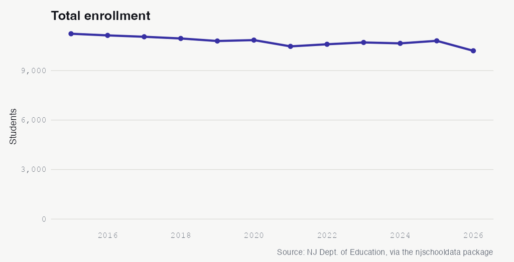

See the underlying data ›

No. 2 ACHIEVEMENT

## Cherry Hill’s Math Scores Still Sit 3.4 Points Below 2019 — Five Years After COVID Closed Schools

NJSLA proficiency in grades 3-8 fell sharply in the pandemic and has only partly recovered, leaving both math and reading below their pre-COVID marks.

When schools reopened, Cherry Hill’s youngest test-takers came back behind. NJSLA reading proficiency for grades 3-8 fell from 69.8% in 2019 to 58.7% in 2022, an 11.1-point drop. Math fell from 54.0% to 45.6% over the same window. Both were the lowest marks in the district’s NJSLA record.

The rebound has been real but incomplete. ELA recovered to 62.7% in 2023 and held at 62.5% in 2024 — still 7.3 points under 2019. Math climbed to 48.8% then 50.6%, leaving it 3.4 points shy of where it stood before the pandemic. In other words, after two years of recovery, the average Cherry Hill elementary or middle-schooler is still less likely to read or do math at grade level than a peer was in 2019.

Math also tells a longer story: even in 2019, barely half the district’s grade 3-8 students were proficient, and that has been the pattern since at least 2017 (52.3%). The open question is whether the post-COVID plateau at roughly 62% ELA and 50% math is the new ceiling or a way station back to pre-pandemic levels.

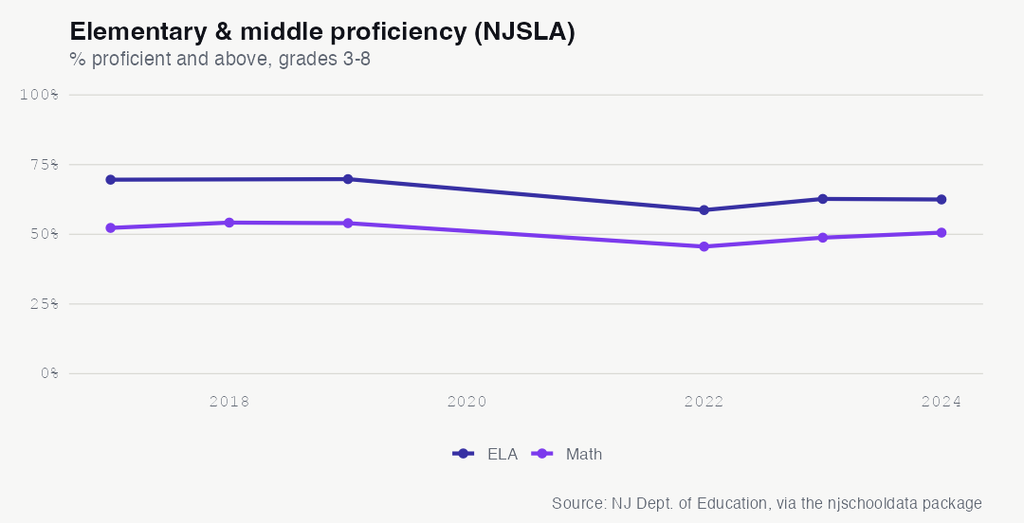

See the underlying data ›

No. 3 FINANCE

## Cherry Hill’s Per-Pupil Spending Rank Fell From 27th to 48th in a Decade Even as Dollars Rose 46%

The district spent $18,916 per student in 2024, well below the DFG GH peer median of $20,442 — and its standing among peers has slid almost every year.

Cherry Hill is spending more money than ever and falling further behind its peers at the same time. Per-pupil spending rose from $12,928 in 2014 to $18,916 in 2024, a 46.3% increase. Yet over that same decade the district’s spending rank dropped from 27th to 48th, sliding in nearly every year on record. At $18,916, Cherry Hill now sits at the 30th percentile of its 76 DFG GH peers, $1,526 below the peer median of $20,442.

Part of the squeeze is enrollment math working against the district: average daily enrollment actually fell over the decade, from 11,270 to 10,647, so rising total dollars are being divided among fewer students yet still trailing peers. Where the money goes is relatively lean on overhead — 63.2% of 2025 spending went to classroom instruction and 9.5% to administration.

For a district that posts strong AP and graduation numbers, the spending data raises a pointed board-level question: how is Cherry Hill sustaining those outcomes while its per-pupil investment slips toward the bottom third of its peer group?

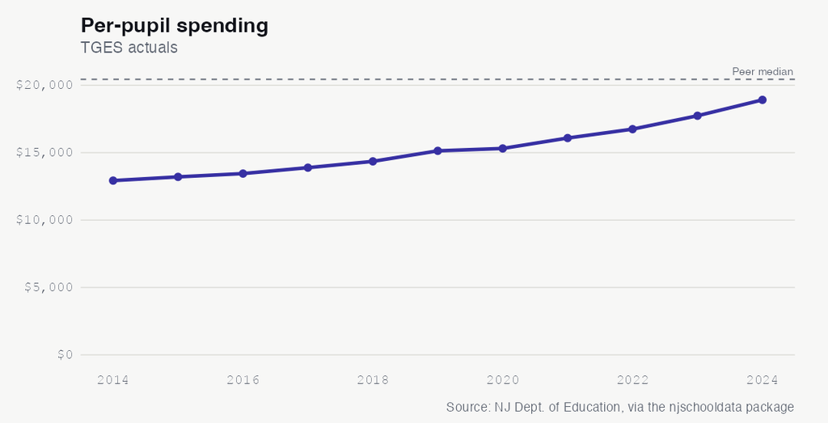

See the underlying data ›

No. 4 EQUITY

## A 25-Point Reading Gap: Cherry Hill’s White and Asian Students Pass NJSLA at Far Higher Rates Than Black and Hispanic Peers

In 2024, 74% of Asian and 68% of white students in grades 3-8 met the ELA bar, versus 43% of Black and Hispanic students.

The steepest divides fall along program lines. Students receiving special education services passed at 26.2%, and current multilingual learners at just 10.4% — though that last figure reflects students still acquiring English being tested in it, a known feature of the data rather than a measure of overall ability.

These gaps are not unique to Cherry Hill, but their size in a high-performing, well-resourced district is the kind of finding that drives equity planning. The data raises a question it cannot answer: are these gaps narrowing, holding, or widening as the district’s post-COVID recovery continues?

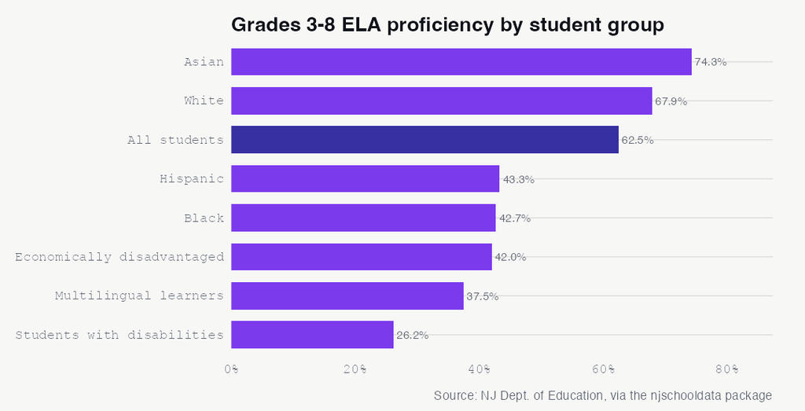

See the underlying data ›

No. 5 DEMOGRAPHICS

## Cherry Hill Just Crossed a Demographic Line: White Students Are Now Exactly Half of Enrollment, Down From 62%

The white share of enrollment fell 11.9 points since 2015 while Hispanic and multiracial enrollment grew steadily.

For the first time in the district’s recent record, white students no longer make up a majority cushion at Cherry Hill — they are exactly half. The white share of enrollment slid from 61.9% in 2015 to 50.0% in 2026, a drop of 11.9 percentage points and the single largest demographic change in the district over that period.

The shift has been gradual and steady rather than abrupt, ticking down almost every year. Meanwhile the Hispanic share rose 6.1 points (to 16.0%) and the multiracial share rose 2.7 points (to 6.0%). The Black share edged up from 8.0% to 10.1%, and the Asian share held remarkably steady around 17.5% throughout.

A district that is becoming more racially and ethnically varied, even as its total enrollment shrinks, faces a familiar set of questions about whether staffing, curriculum, and programming keep pace. The data marks the trend clearly; it cannot say what it means for how the district serves its changing student body.

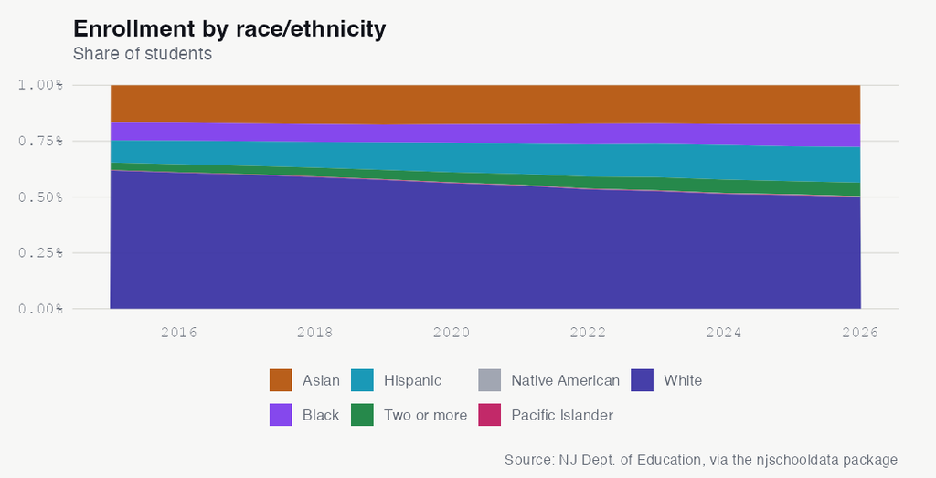

See the underlying data ›

No. 6 ATTENDANCE

## Chronic Absenteeism in Cherry Hill Sits at 13.5% — Four Points Above the Peer Median

More than one in eight students missed at least 10% of school days in 2024, up from fewer than one in ten before the pandemic.

Cherry Hill’s chronic absenteeism rate was 13.5% in 2024 — meaning more than one in eight students missed at least 10% of the school year. That is nearly four points above the DFG GH peer median of 9.6% and well above the district’s own pre-pandemic mark of 9.5% in 2019.

The pattern tracks the pandemic almost too neatly. Absenteeism actually dipped to 7.1% in the remote-heavy 2021 year, then spiked to 14.8% in 2022 and 15.3% in 2023 as students returned to buildings. The 2024 figure of 13.5% is an improvement on that peak but still leaves the district elevated relative to both its own history and its peers.

Chronic absenteeism is one of the strongest early-warning signals in education data, closely tied to achievement and graduation outcomes. With Cherry Hill’s NJSLA scores still below 2019, the unanswered question is how much of the lagging recovery is tied to students simply not being in class.

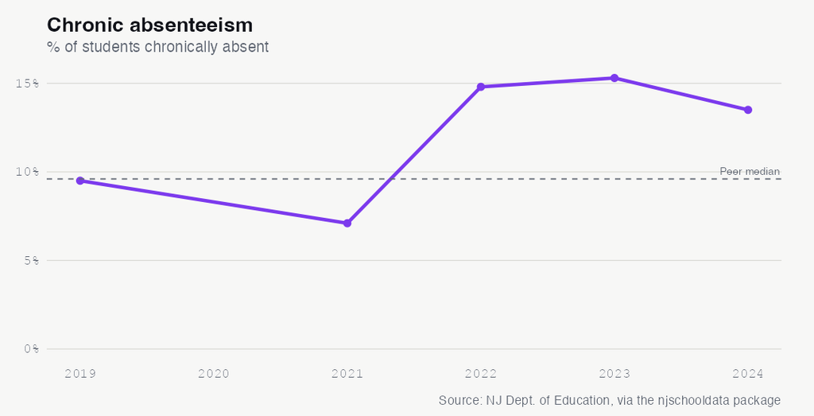

See the underlying data ›

No. 7 GRADUATION

## Cherry Hill’s Graduation Rate Is 95% — But That Ranks Only 41st Percentile Among Its 76 Peers

A number that looks like success statewide places the district in the bottom half of its District Factor Group.

Cherry Hill graduated 95.2% of its 2025 cohort, a figure that sounds like an unambiguous win — and in isolation, it is. But measured against the company it keeps, the picture flattens. Among the 76 districts in its District Factor Group GH, that rate lands at just the 41st percentile, below the peer median of 96.1%.

The rate has been steady, hovering between 94.1% and 95.7% across the six years on record, with no clear upward trend. The story isn’t decline; it’s a high plateau in a peer group where 95% is merely average.

For families choosing among similar suburban districts, this is the kind of context that a single headline number obscures. The data poses a board-level question: in a group of high-graduating districts, what separates the ones above the median from the ones, like Cherry Hill, sitting just below it?

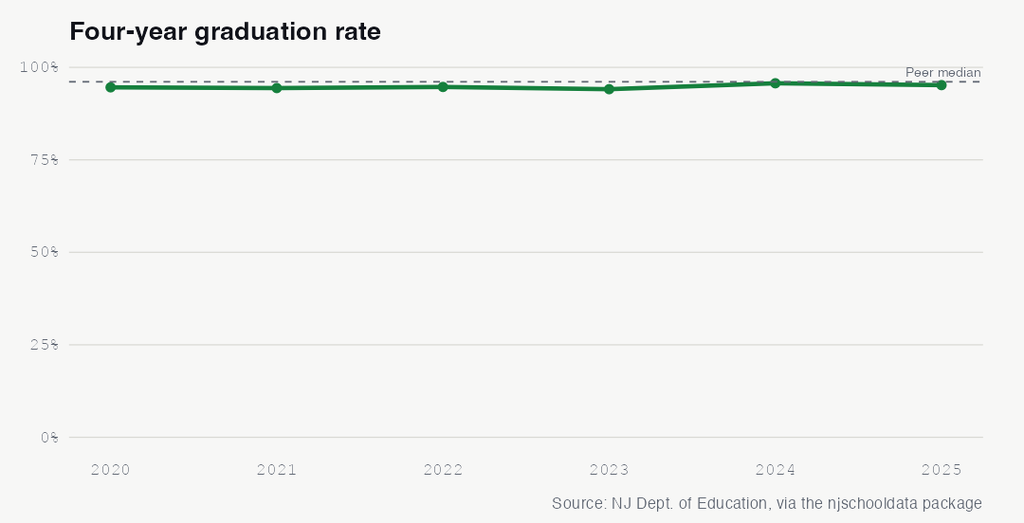

See the underlying data ›

No. 8 EQUITY

## A 12-Point Graduation Gap Separates Cherry Hill’s White Students From Its Students With Disabilities

While 97% of white and Asian seniors graduated in 2025, the rate fell to 85% for students with disabilities and 80% for multilingual learners.

Cherry Hill’s overall 95.2% graduation rate holds together because its largest groups graduate at very high rates: 97.0% of white students and 97.3% of Asian students in the 2025 cohort. The gaps open up underneath. Black students graduated at 90.1% and Hispanic students at 91.1% — both meaningfully below the white rate.

The widest divides are by program and need. Students with disabilities graduated at 85.2%, nearly 12 points below the white rate, and multilingual learners at 80.0% on a small cohort of 25 students. Students who are economically disadvantaged graduated at 93.3%, closer to the average but still trailing their peers.

These are the subgroups that overall rates are designed to surface. In a district where 95% graduation reads as success, the data points to specific populations for whom the experience is measurably different — and asks whether targeted supports are closing those gaps year over year.

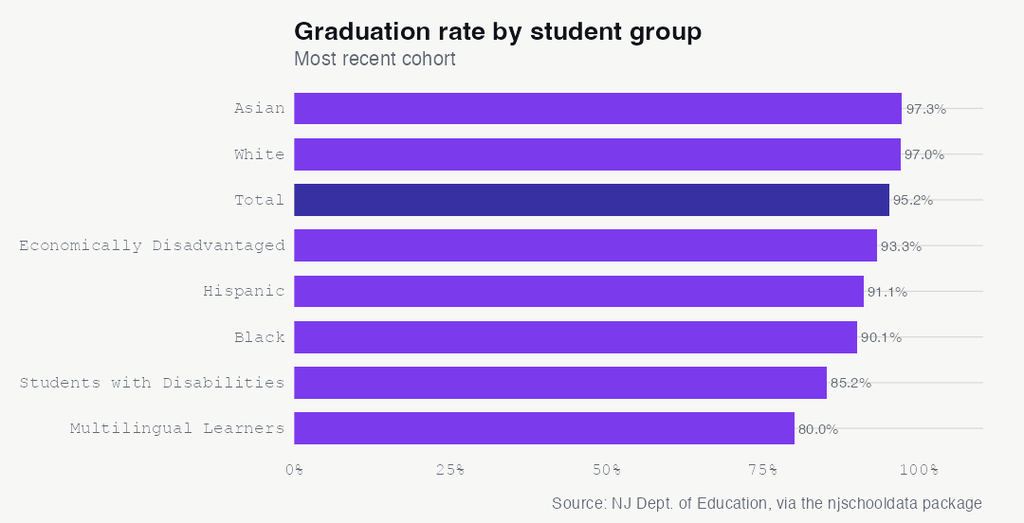

See the underlying data ›

No. 9 DEMOGRAPHICS

## Economic Need at Cherry Hill Jumped From 16% to 24% in Just Four Years

The share of students qualifying for free or reduced-price lunch reversed a long decline after 2022, climbing to its highest level on record.

For most of the past decade, Cherry Hill looked like a district growing more affluent. The share of students qualifying for free or reduced-price lunch fell steadily from 20.4% in 2015 to a low of 15.9% in 2022. Then it reversed hard: 18.3% in 2023, 20.2% in 2024, 23.2% in 2025, and 23.9% in 2026 — the highest share on record and an 8-point jump in four years.

The same period saw multilingual learners more than double, from 2.3% of students in 2015 to 5.2% in 2026. Together the two trends suggest a student body with rising need arriving even as total enrollment falls.

This matters for resourcing in a district whose per-pupil spending already trails its peer median. The data documents a sharp rise in economic need; it cannot say whether budgets and programs are being recalibrated to match it.

See the underlying data ›

No. 10 COLLEGE READINESS

## Cherry Hill’s SAT Participation Slid From 92% to 75% — Even as Advanced-Coursework Success Stayed Strong

Nearly 40% of students still score 3+ on an AP or IB exam, far above the state, but a once-near-universal college-entrance test now reaches three in four.

The SAT tells a quieter, downward story. The share of the grade taking the test fell from 91.7% in 2019 to 74.9% in 2024 — still above the statewide 62.7%, but a decline of nearly 17 points. The drop began in the disrupted 2021 testing year (75.9%) and never fully recovered.

The two trends sit in tension: advanced-coursework success holds strong while a once-near-universal college-entrance exam reaches a shrinking share of students. The data leaves open whether that reflects a national shift toward test-optional admissions or something more local.

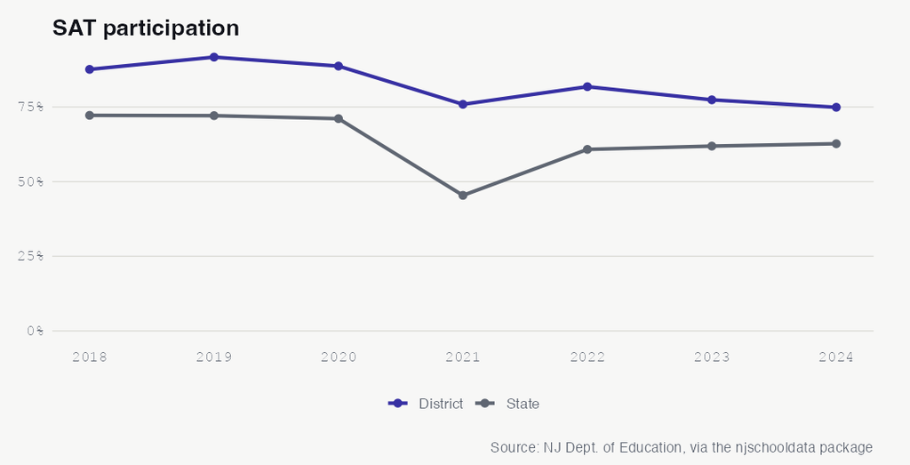

See the underlying data ›

## The Almanac

The full longitudinal record behind the stories above. Every number a reader can check.

### Enrollment (total)

| year | students | yoy | yoy_pct |
| --- | --- | --- | --- |
| 2015 | 11234 | NA | NA |
| 2016 | 11134 | -100 | -0.9 |
| 2017 | 11051 | -83 | -0.7 |
| 2018 | 10948 | -103 | -0.9 |
| 2019 | 10794 | -154 | -1.4 |
| 2020 | 10849 | 55 | 0.5 |
| 2021 | 10469 | -380 | -3.5 |
| 2022 | 10596 | 127 | 1.2 |
| 2023 | 10706 | 110 | 1 |
| 2024 | 10651 | -55 | -0.5 |
| 2025 | 10805 | 154 | 1.4 |
| 2026 | 10202 | -603 | -5.6 |

### Demographic share (%) by year

| end_year | white | black | hispanic | asian | native_american | pacific_islander | multiracial |
| --- | --- | --- | --- | --- | --- | --- | --- |
| 2015 | 61.9 | 8 | 9.9 | 16.7 | 0 | 0.2 | 3.3 |
| 2016 | 60.9 | 8.1 | 10.5 | 16.7 | 0 | 0.2 | 3.6 |
| 2017 | 60 | 7.9 | 11 | 17.1 | 0 | 0.2 | 3.7 |
| 2018 | 58.9 | 8 | 11.5 | 17.4 | 0 | 0.3 | 4 |
| 2019 | 57.6 | 7.9 | 12.3 | 17.6 | 0.1 | 0.3 | 4.2 |
| 2020 | 56.2 | 8.2 | 13.2 | 17.5 | 0.1 | 0.3 | 4.5 |
| 2021 | 55.2 | 8.8 | 13.5 | 17.4 | 0.1 | 0.2 | 4.8 |
| 2022 | 53.4 | 9.3 | 14.4 | 17.2 | 0.1 | 0.2 | 5.3 |
| 2023 | 52.6 | 9.1 | 14.9 | 17.1 | 0.1 | 0.2 | 5.9 |
| 2024 | 51.4 | 9.4 | 15.5 | 17.4 | 0.2 | 0.2 | 6 |
| 2025 | 50.8 | 9.9 | 15.6 | 17.5 | 0.2 | 0.3 | 5.8 |
| 2026 | 50 | 10.1 | 16 | 17.5 | 0.2 | 0.2 | 6 |

### Special populations (LEP, FRL)

| end_year | subgroup | students | pct |
| --- | --- | --- | --- |
| 2015 | lep | 258 | 2.3 |
| 2015 | free_reduced_lunch | 2290 | 20.4 |
| 2016 | lep | 252 | 2.3 |
| 2016 | free_reduced_lunch | 2227 | 20.0 |
| 2017 | lep | 242 | 2.2 |
| 2017 | free_reduced_lunch | 2184 | 19.8 |
| 2018 | lep | 299 | 2.7 |
| 2018 | free_reduced_lunch | 2119 | 19.4 |
| 2019 | lep | 355 | 3.3 |
| 2019 | free_reduced_lunch | 2146 | 19.9 |
| 2020 | lep | 380 | 3.5 |
| 2020 | free_reduced_lunch | 1931 | 17.8 |
| 2021 | lep | 356 | 3.4 |
| 2021 | free_reduced_lunch | 1926 | 18.4 |
| 2022 | lep | 371 | 3.5 |
| 2022 | free_reduced_lunch | 1685 | 15.9 |
| 2023 | lep | 407 | 3.8 |
| 2023 | free_reduced_lunch | 1959 | 18.3 |
| 2024 | lep | 405 | 3.8 |
| 2024 | free_reduced_lunch | 2152 | 20.2 |
| 2025 | lep | 573 | 5.3 |
| 2025 | free_reduced_lunch | 2507 | 23.2 |
| 2026 | lep | 531 | 5.2 |
| 2026 | free_reduced_lunch | 2438 | 23.9 |

### Graduation rate 4yr (total)

| year | grad_rate | cohort |
| --- | --- | --- |
| 2020 | 94.6 | 909 |
| 2021 | 94.4 | 930 |
| 2022 | 94.7 | 922 |
| 2023 | 94.1 | 888 |
| 2024 | 95.7 | 913 |
| 2025 | 95.2 | 877 |

### Graduation by subgroup (2025)

| subgroup | grad_rate | cohort |
| --- | --- | --- |
| asian | 97.3 | 146 |
| white | 97.0 | 467 |
| female | 96.3 | NA |
| total | 95.2 | 877 |
| multiracial | 94.6 | NA |
| male | 94.5 | 472 |
| economically disadvantaged | 93.3 | 268 |
| hispanic | 91.1 | 124 |
| black | 90.1 | 101 |
| students with disabilities | 85.2 | 135 |
| multilingual learners | 80.0 | 25 |
| american indian | NA | NA |
| migrant students | NA | NA |
| military-connected students | NA | NA |
| non-binary/undesignated gender | NA | NA |
| students experiencing homelessness | NA | NA |
| students in foster care | NA | NA |

### NJGPA high-school proficiency (% proficient+)

| year | test | prof_above | valid |
| --- | --- | --- | --- |
| 2023 | ela | 88.6 | 874 |
| 2023 | math | 68.5 | 875 |
| 2024 | ela | NA | NA |
| 2024 | math | 66.5 | 835 |
| 2025 | ela | NA | NA |
| 2025 | math | 69.4 | 869 |

### NJGPA ELA by subgroup (2025)

[output not shown]

### NJSLA grades 3-8 proficiency (% proficient+, enrollment-weighted across grades)

| testing_year | test_name | prof |
| --- | --- | --- |
| 2017 | ela | 69.6 |
| 2017 | math | 52.3 |
| 2018 | math | 54.2 |
| 2019 | ela | 69.8 |
| 2019 | math | 54.0 |
| 2022 | ela | 58.7 |
| 2022 | math | 45.6 |
| 2023 | ela | 62.7 |
| 2023 | math | 48.8 |
| 2024 | ela | 62.5 |
| 2024 | math | 50.6 |

### NJSLA ELA proficiency by subgroup (2024, grades 3-8)

| subgroup | prof |
| --- | --- |
| asian | 74.3 |
| FORMER - ML | 68.1 |
| white | 67.9 |
| female | 67.6 |
| non_ed | 66.8 |
| other | 63.4 |
| total_population | 62.5 |
| male | 58.8 |
| lep_former | 50.0 |
| hispanic | 43.3 |
| black | 42.7 |
| ed | 42.0 |
| lep_current_former | 38.8 |
| MULTILINGUAL LEARNERS | 37.5 |
| sped_accomodations | 27.3 |
| special_education | 26.2 |
| CURRENT - ML | 14.2 |
| lep_current | 10.4 |

### Chronic absenteeism (% chronically absent)

| year | chronic_pct |
| --- | --- |
| 2019 | 9.5 |
| 2021 | 7.1 |
| 2022 | 14.8 |
| 2023 | 15.3 |
| 2024 | 13.5 |

### Disciplinary removals

[output not shown]

### Police notifications (incident counts)

| year | violence | weapons | vandalism | substances | hib | other |
| --- | --- | --- | --- | --- | --- | --- |
| 2019 | 36 | 5 | 7 | 19 | 5 | 0 |
| 2020 | 19 | 1 | 4 | 9 | 1 | 0 |
| 2021 | 5 | 0 | 0 | 1 | 0 | 0 |
| 2022 | 42 | 13 | 6 | 9 | 4 | 0 |
| 2023 | 34 | 4 | 1 | 13 | 4 | 0 |
| 2024 | 22 | 7 | 2 | 19 | 0 | 0 |

### HIB (harassment/intimidation/bullying) investigations

| end_year | alleged | confirmed |
| --- | --- | --- |
| 2019 | 103 | 106 |
| 2020 | 60 | 35 |
| 2021 | 26 | 9 |
| 2022 | 91 | 85 |
| 2023 | 181 | 92 |
| 2024 | 202 | 101 |

### SAT participation (% of grade)

| year | sat_part | state_sat |
| --- | --- | --- |
| 2018 | 87.6 | 72.2 |
| 2019 | 91.7 | 72.1 |
| 2020 | 88.7 | 71.1 |
| 2021 | 75.9 | 45.4 |
| 2022 | 81.8 | 60.8 |
| 2023 | 77.4 | 61.9 |
| 2024 | 74.9 | 62.7 |

### AP/IB & dual enrollment (% of students)

| year | apib_coursework | apib_exam | ap3_ib4 | state_ap3_ib4 | dual |
| --- | --- | --- | --- | --- | --- |
| 2018 | 53.9 | 40.1 | 34.1 | 20.5 | 0 |
| 2019 | 55.9 | 46.5 | 38.9 | 20.7 | 74.1 |
| 2020 | 60 | 48.2 | 41 | 22.8 | 79.3 |
| 2021 | 56.3 | 37.1 | 31.2 | 17.9 | 71.1 |
| 2022 | 58.6 | 43 | 33.4 | 19.9 | 75.4 |
| 2023 | 62.5 | 47.7 | 39.2 | 21.3 | 72.1 |
| 2024 | 61.5 | 47.4 | 39.8 | 23 | 65.1 |

### Special education (raw rows; inspect for classification rate)

| end_year | district_id |
| --- | --- |
| 2024 | 0800 |

### Per-pupil spending (TGES actuals)

| year | per_pupil | rank | ade |
| --- | --- | --- | --- |
| 2014 | 12928 | 27 | 11270 |
| 2015 | 13204 | 26 | 11244 |
| 2016 | 13448 | 31 | 11141 |
| 2017 | 13887 | 28 | 11105 |
| 2018 | 14354 | 29 | 10946 |
| 2019 | 15136 | 33 | 10816 |
| 2020 | 15312 | 35 | 10857 |
| 2021 | 16085 | 43 | 10487 |
| 2022 | 16745 | 40 | 10659 |
| 2023 | 17738 | 46 | 10713 |
| 2024 | 18916 | 48 | 10647 |

### Spending composition shares (2025)

| classroom_share | support_services_share | administration_share | plant_ops_share | food_service_share | extracurricular_share | equipment_share |
| --- | --- | --- | --- | --- | --- | --- |
| 63.2 | 17.2 | 9.5 | 8.6 | NA | 1.5 | 0.7 |

### Staffing ratios

| end_year | student_teacher_district | student_admin_district | student_counselor_district | student_nurse_district |
| --- | --- | --- | --- | --- |
| 2024 | 12:1 | 219:1 | 268:1 | 488:1 |

Back to top